# Project 2: Bank marketing dataset

Author

Group 17

# 1 Introduction

# 2 Exploratory Analysis

```
      age            job              marital           education
 Min.   :17.00   Length:10000       Length:10000       Length:10000
 1st Qu.:32.00   Class :character   Class :character   Class :character
 Median :38.00   Mode  :character   Mode  :character   Mode  :character
 Mean   :40.07
 3rd Qu.:47.00
 Max.   :95.00
   default            housing              loan             contact
 Length:10000       Length:10000       Length:10000       Length:10000
 Class :character   Class :character   Class :character   Class :character
 Mode  :character   Mode  :character   Mode  :character   Mode  :character



    month           day_of_week           duration         campaign
 Length:10000       Length:10000       Min.   :   1.0   Min.   : 1.000
 Class :character   Class :character   1st Qu.: 103.0   1st Qu.: 1.000
 Mode  :character   Mode  :character   Median : 180.0   Median : 2.000
                                       Mean   : 260.5   Mean   : 2.593
                                       3rd Qu.: 321.0   3rd Qu.: 3.000
                                       Max.   :4918.0   Max.   :37.000
     pdays          previous        poutcome          emp.var.rate
 Min.   :  0.0   Min.   :0.0000   Length:10000       Min.   :-3.40000
 1st Qu.:999.0   1st Qu.:0.0000   Class :character   1st Qu.:-1.80000
 Median :999.0   Median :0.0000   Mode  :character   Median : 1.10000
 Mean   :961.1   Mean   :0.1794                      Mean   : 0.06577
 3rd Qu.:999.0   3rd Qu.:0.0000                      3rd Qu.: 1.40000
 Max.   :999.0   Max.   :7.0000                      Max.   : 1.40000
 cons.price.idx  cons.conf.idx      euribor3m      nr.employed
 Min.   :92.20   Min.   :-50.80   Min.   :0.634   Min.   :4964
 1st Qu.:93.08   1st Qu.:-42.70   1st Qu.:1.334   1st Qu.:5099
 Median :93.44   Median :-41.80   Median :4.857   Median :5191
 Mean   :93.57   Mean   :-40.51   Mean   :3.604   Mean   :5166
 3rd Qu.:93.99   3rd Qu.:-36.40   3rd Qu.:4.961   3rd Qu.:5228
 Max.   :94.77   Max.   :-26.90   Max.   :5.045   Max.   :5228
      y
 Length:10000
 Class :character
 Mode  :character
```

Data summary

| Name | bank |
| --- | --- |
| Number of rows | 10000 |
| Number of columns | 21 |
| _______________________ |  |
| Column type frequency: |  |
| character | 11 |
| numeric | 10 |
| ________________________ |  |
| Group variables | None |

**Variable type: character**

| skim_variable | n_missing | complete_rate | min | max | empty | n_unique | whitespace |
| --- | --- | --- | --- | --- | --- | --- | --- |
| job | 0 | 1 | 6 | 13 | 0 | 12 | 0 |
| marital | 0 | 1 | 6 | 8 | 0 | 4 | 0 |
| education | 0 | 1 | 7 | 19 | 0 | 8 | 0 |
| default | 0 | 1 | 2 | 7 | 0 | 2 | 0 |
| housing | 0 | 1 | 2 | 7 | 0 | 3 | 0 |
| loan | 0 | 1 | 2 | 7 | 0 | 3 | 0 |
| contact | 0 | 1 | 8 | 9 | 0 | 2 | 0 |
| month | 0 | 1 | 3 | 3 | 0 | 10 | 0 |
| day_of_week | 0 | 1 | 3 | 3 | 0 | 5 | 0 |
| poutcome | 0 | 1 | 7 | 11 | 0 | 3 | 0 |
| y | 0 | 1 | 2 | 3 | 0 | 2 | 0 |

**Variable type: numeric**

| skim_variable | n_missing | complete_rate | mean | sd | p0 | p25 | p50 | p75 | p100 | hist |
| --- | --- | --- | --- | --- | --- | --- | --- | --- | --- | --- |
| age | 0 | 1 | 40.07 | 10.52 | 17.00 | 32.00 | 38.00 | 47.00 | 95.00 | ▅▇▃▁▁ |
| duration | 0 | 1 | 260.46 | 266.65 | 1.00 | 103.00 | 180.00 | 321.00 | 4918.00 | ▇▁▁▁▁ |
| campaign | 0 | 1 | 2.59 | 2.80 | 1.00 | 1.00 | 2.00 | 3.00 | 37.00 | ▇▁▁▁▁ |
| pdays | 0 | 1 | 961.07 | 190.32 | 0.00 | 999.00 | 999.00 | 999.00 | 999.00 | ▁▁▁▁▇ |
| previous | 0 | 1 | 0.18 | 0.51 | 0.00 | 0.00 | 0.00 | 0.00 | 7.00 | ▇▁▁▁▁ |
| emp.var.rate | 0 | 1 | 0.07 | 1.57 | -3.40 | -1.80 | 1.10 | 1.40 | 1.40 | ▁▃▁▁▇ |
| cons.price.idx | 0 | 1 | 93.57 | 0.58 | 92.20 | 93.08 | 93.44 | 93.99 | 94.77 | ▁▆▃▇▂ |
| cons.conf.idx | 0 | 1 | -40.51 | 4.65 | -50.80 | -42.70 | -41.80 | -36.40 | -26.90 | ▅▇▁▇▁ |
| euribor3m | 0 | 1 | 3.60 | 1.74 | 0.63 | 1.33 | 4.86 | 4.96 | 5.04 | ▅▁▁▁▇ |
| nr.employed | 0 | 1 | 5166.24 | 72.43 | 4963.60 | 5099.10 | 5191.00 | 5228.10 | 5228.10 | ▁▁▃▁▇ |

Figure 1 This chart illustrates the uneven distribution of the target variable y: the proportion of non-subscribed clients reaches 88.8%, while the proportion of successfully converted clients is only 11.2%. Due to this distribution characteristic, our subsequent logistic regression model may exhibit certain bias during the fitting process. Therefore, when evaluating the model’s performance, we do not solely rely on the overall accuracy rate (because even if the model predicts all results as “no”, the final accuracy rate can still exceed 80%). On the other hand, we will pay more attention to the model’s ability to identify these 11.21% key samples, so that the final prediction results have practical reference value.

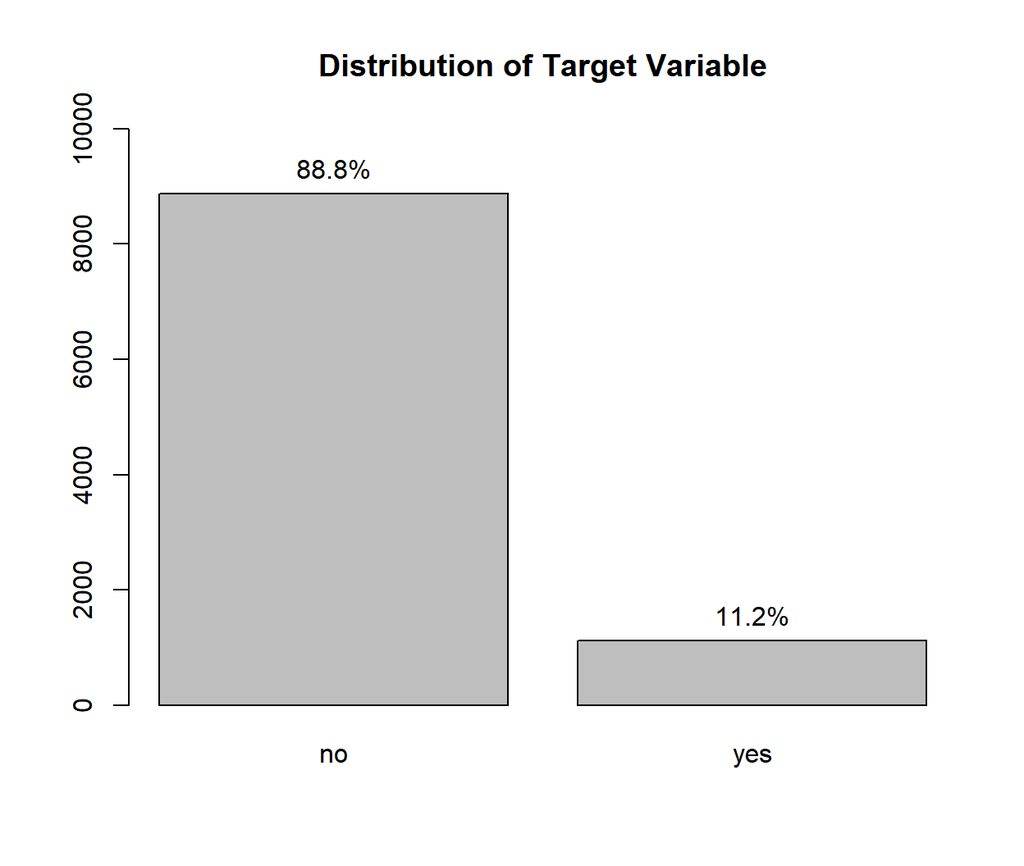

Figure 1: Distribution of Target Variable

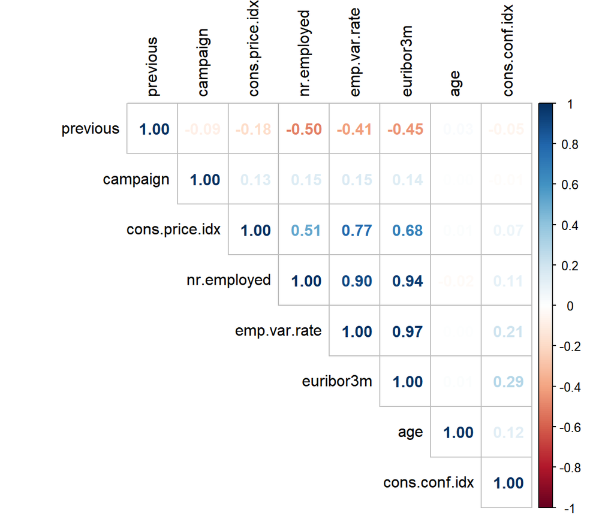

Figure 2: Correlation Matrix of Numerical Variables

Table 1: Principal Component Loadings

Principal Component Loadings

First two principal components

| variable | Comp.1 | Comp.2 |
| --- | --- | --- |
| age | 0.00 | 0.69 |
| campaign | 0.11 | −0.22 |
| previous | −0.28 | 0.16 |
| emp.var.rate | 0.51 | 0.01 |
| cons.price.idx | 0.39 | −0.02 |
| cons.conf.idx | 0.13 | 0.67 |
| euribor3m | 0.51 | 0.06 |
| nr.employed | 0.48 | −0.08 |

By combining the correlation matrix Figure 2 and Principal Component Analysis Table 1, it can be observed that euribor3m, nr.employed, and emp.var.rate have a high degree of positive correlation (the pairwise correlation coefficients are all greater than 0.9), and multiple collinearity can also be seen in the first principal component (Comp.1). For the subsequent modeling performance, we decided to exclude nr.employed and emp.var.rate and retain euribor3m. Because euribor3m represents the Euro Interbank Offered Rate, it can better reflect the macro-financial situation during bank marketing, and can relatively better help us explain the final subscription situation of clients.

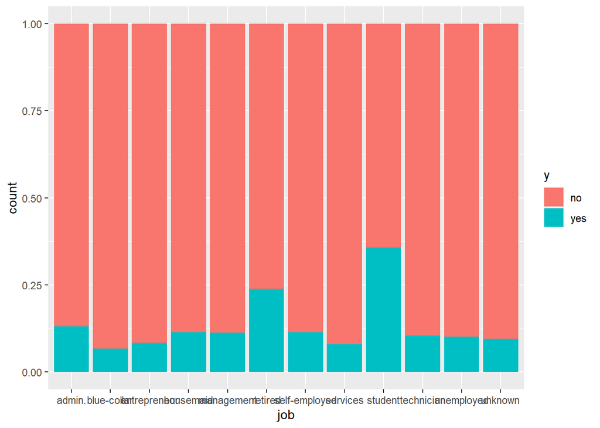

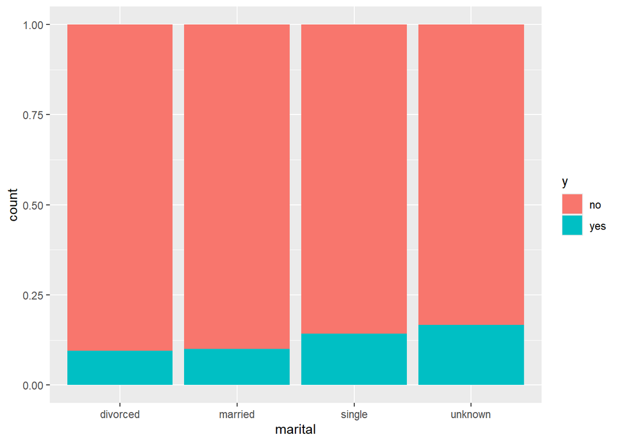

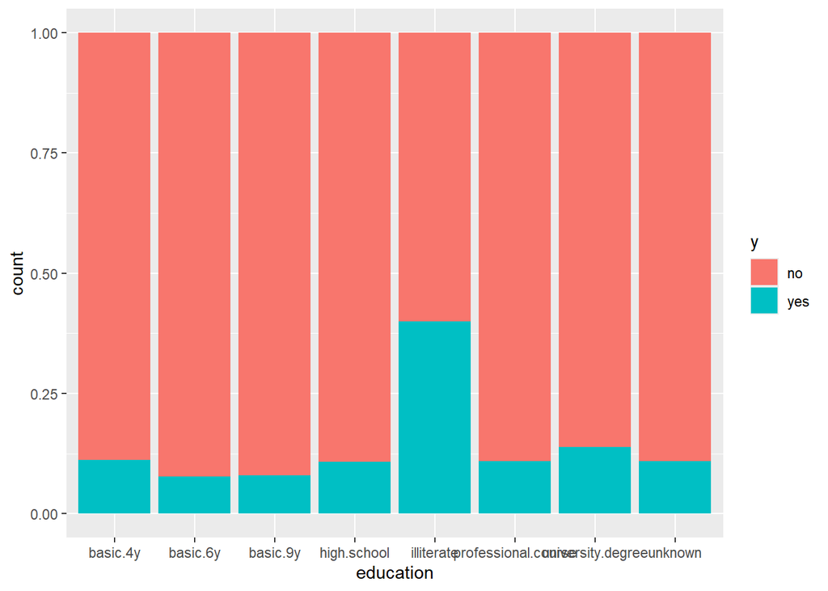

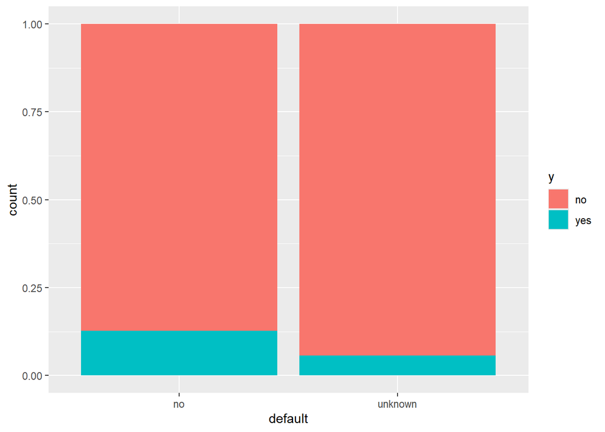

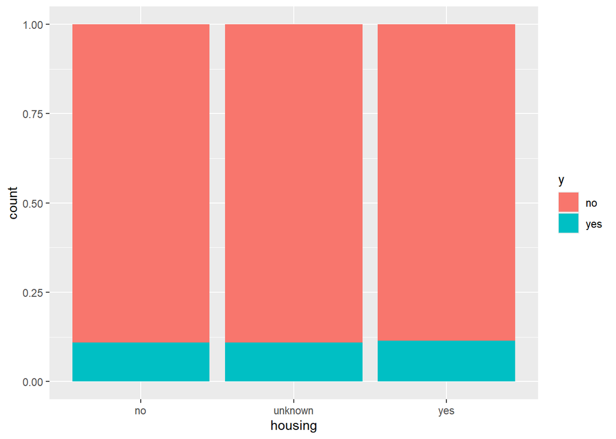

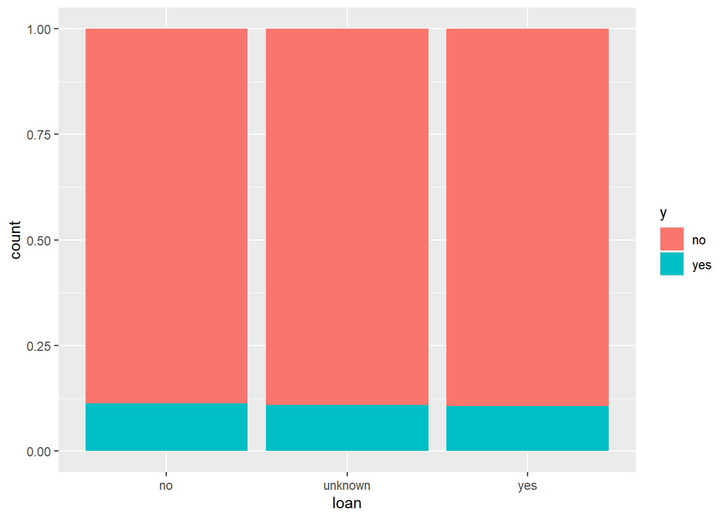

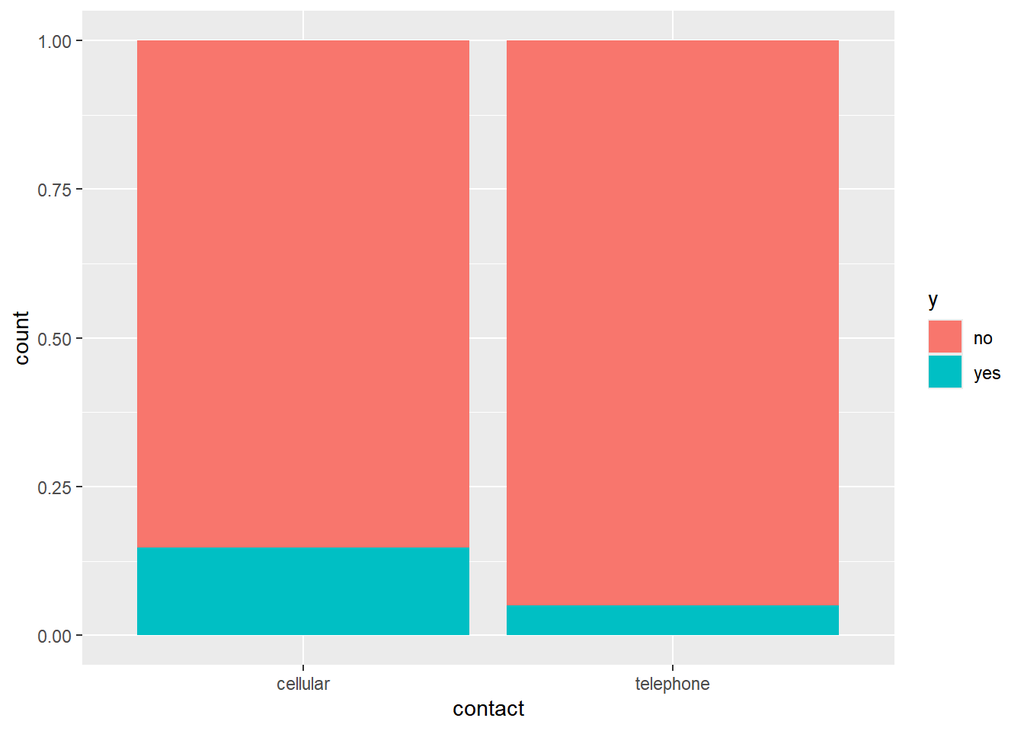

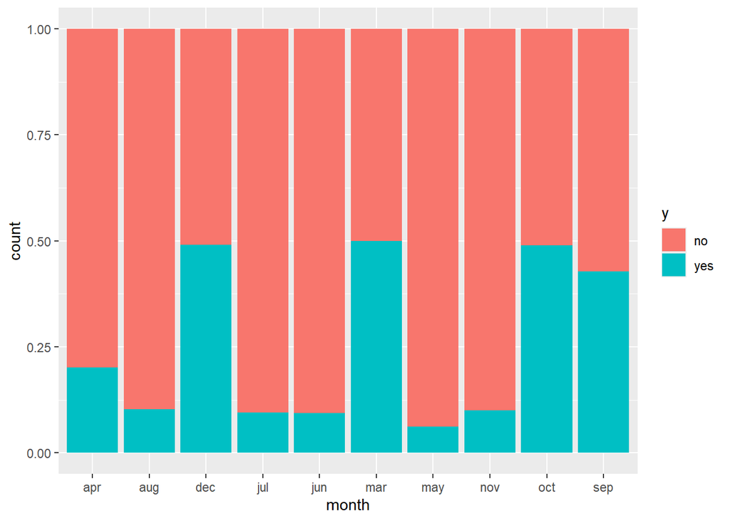

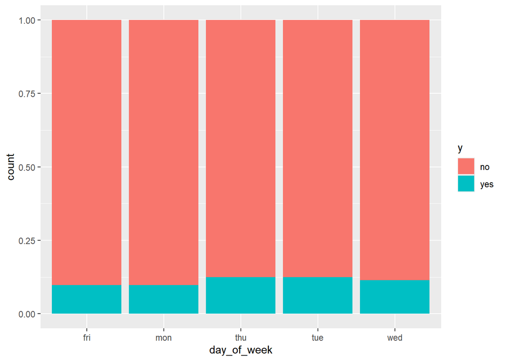

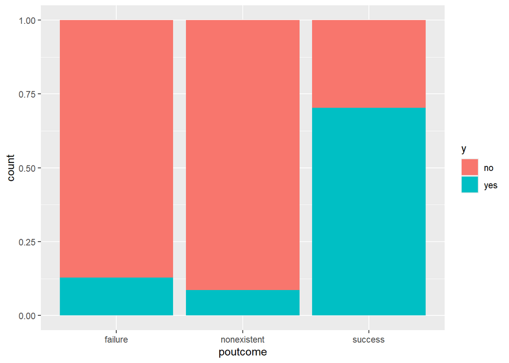

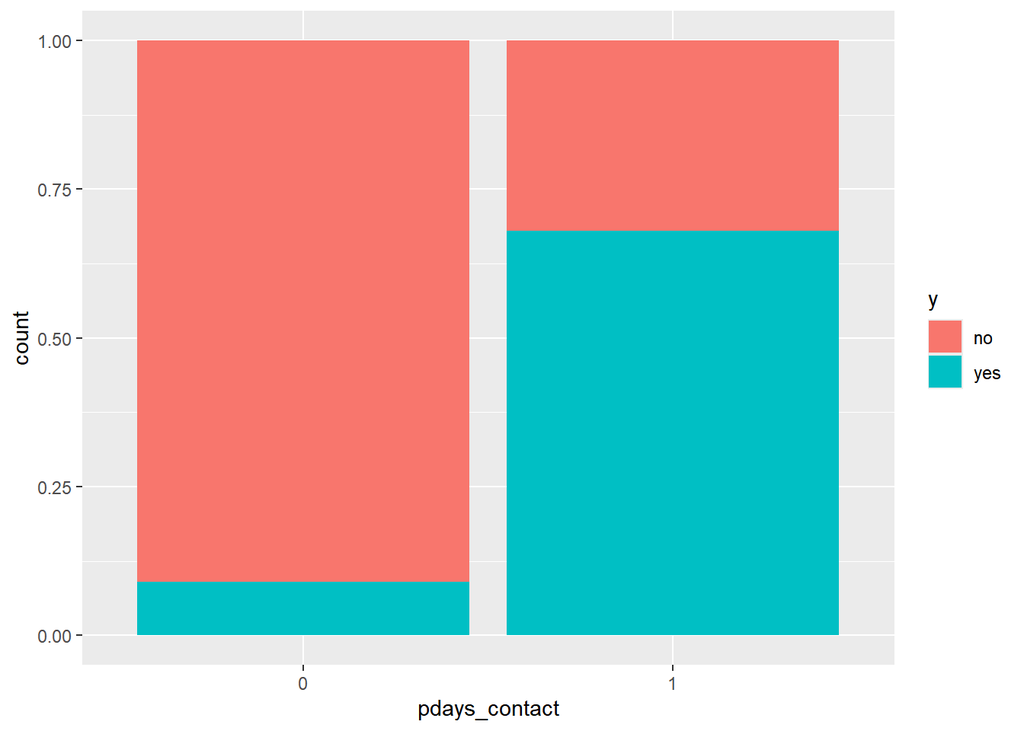

Since the variable default only has two values, “no” and “unknown”, and over 78% of the cases are “no” with no “yes”, the available information is extremely limited. Therefore, we have decided to remove this variable.

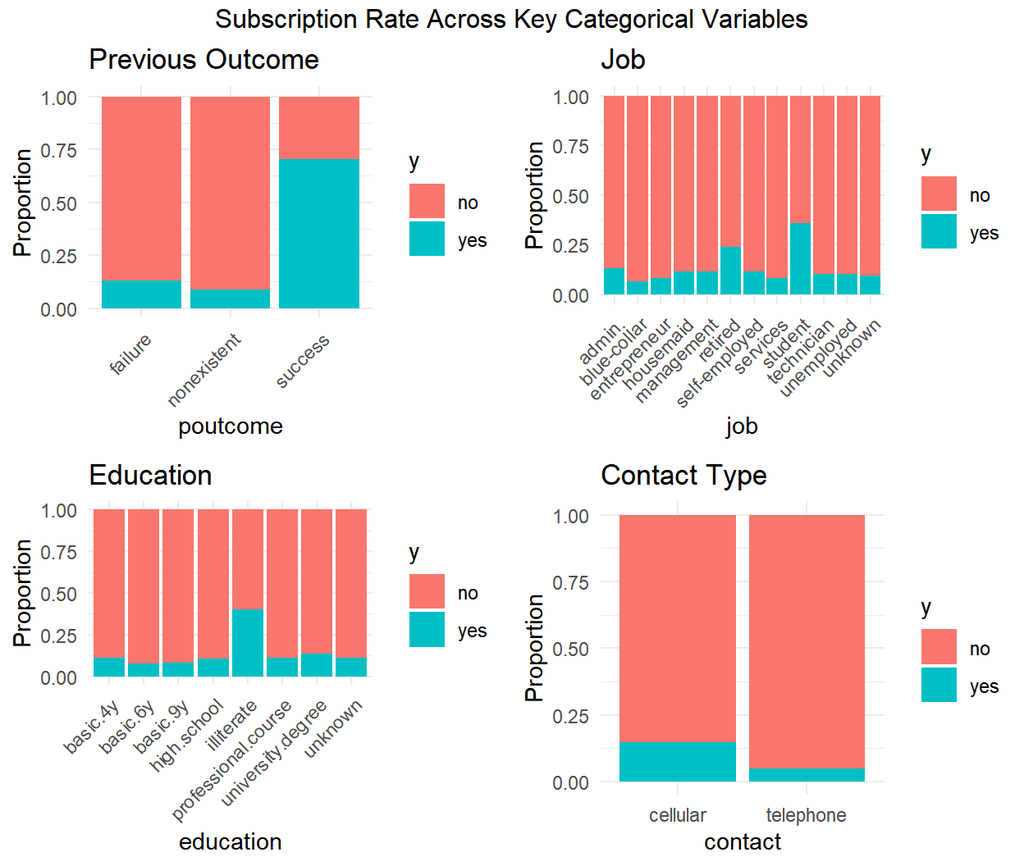

Figure 3: Subscription Rate Across Key Categorical Variables

Figure 3 This set of graphs respectively shows the relationships between several key categorical variables and the variable indicating whether the client subscribes (y). From the graphs, it can be seen that the previous marketing outcome (poutcome) obviously affects whether the client subscribes this time. Clients who were successfully marketed before (success) have a higher probability of subscribing than those who were marketing failed (failure) or had no previous contact (nonexistent). Moreover, there are certain differences between different occupations (job) and educational levels (education), indicating that the social characteristics of the clients may have an impact on the subscription decision. At the same time, there are also certain differences in contact methods (contact), with clients contacted via mobile phone (cellular) having a slightly higher chance of subscribing than those contacted via telephone (telephone).

Overall, historical marketing results, client social characteristics, and communication channels may all have an impact on whether the client subscribes this time. Therefore, these variables will have certain predictive value in the subsequent modeling process.

```
 [1] "age"            "job"            "marital"        "education"
 [5] "housing"        "loan"           "contact"        "month"
 [9] "day_of_week"    "campaign"       "previous"       "poutcome"
[13] "cons.price.idx" "cons.conf.idx"  "euribor3m"      "y"
[17] "pdays_contact"
```

Table 2: Variables Used in the Analysis

Variables Used in the Analysis

Selected variables from the Bank Marketing dataset

| Variable Name | Variable Type | Description |
| --- | --- | --- |
| y | Categorical | Has the client subscribed a term deposit (yes/no) |
| age | Numeric | Age of the client at the contact date |
| job | Categorical | Type of job (e.g., admin, technician, services, etc.) |
| marital | Categorical | Marital status (divorced, married, single) |
| education | Categorical | Education level (basic.4y, basic.6y, basic.9y, high.school, university.degree, etc.) |
| housing | Categorical | Whether the client has a housing loan |
| loan | Categorical | Whether the client has a personal loan |
| contact | Categorical | Contact communication type (cellular or telephone) |
| month | Categorical | Last contact month of the year |
| day_of_week | Categorical | Last contact day of the week |
| campaign | Numeric | Number of contacts performed during this campaign for this client |
| pdays_contact | Categorical | Indicator whether the client has been contacted previously |
| previous | Numeric | Number of contacts performed before this campaign |
| poutcome | Categorical | Outcome of the previous marketing campaign (failure, nonexistent, success) |
| cons.price.idx | Numeric | Consumer price index (monthly indicator) |
| cons.conf.idx | Numeric | Consumer confidence index (monthly indicator) |
| euribor3m | Numeric | Euribor 3-month rate (daily indicator) |

Table 2 This table presents the variables that we ultimately used for the analysis.

```
[1] 8000   17
```

```
[1] 2000   17
```

```
      no      yes
0.888375 0.111625
```

```
   no   yes
0.886 0.114
```

Divide the dataset into a training set and a test set in a ratio of 8:2.

# 3 Formal Analysis

Given the substantial class imbalance in the dataset (88.8% “no”), equal class priors were assigned (`prior = c(0.5, 0.5)`) to prevent the tree from trivially favouring the majority class. Without this adjustment, a tree predicting “no” for every observation would achieve over 88% accuracy while providing no useful predictive information.

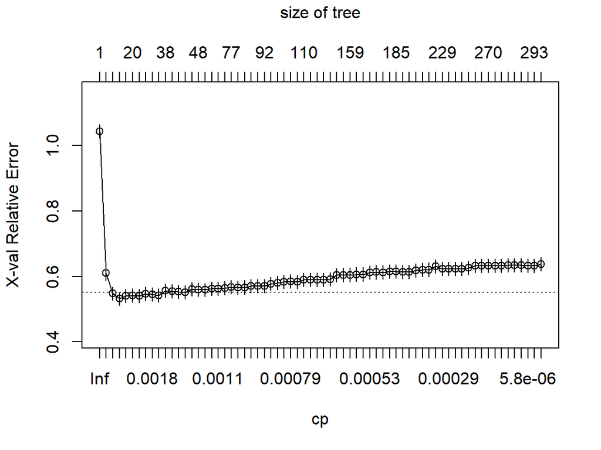

Figure 4: CP Plot for Decision Tree Pruning

### 3.0.1 Model fitting and pruning

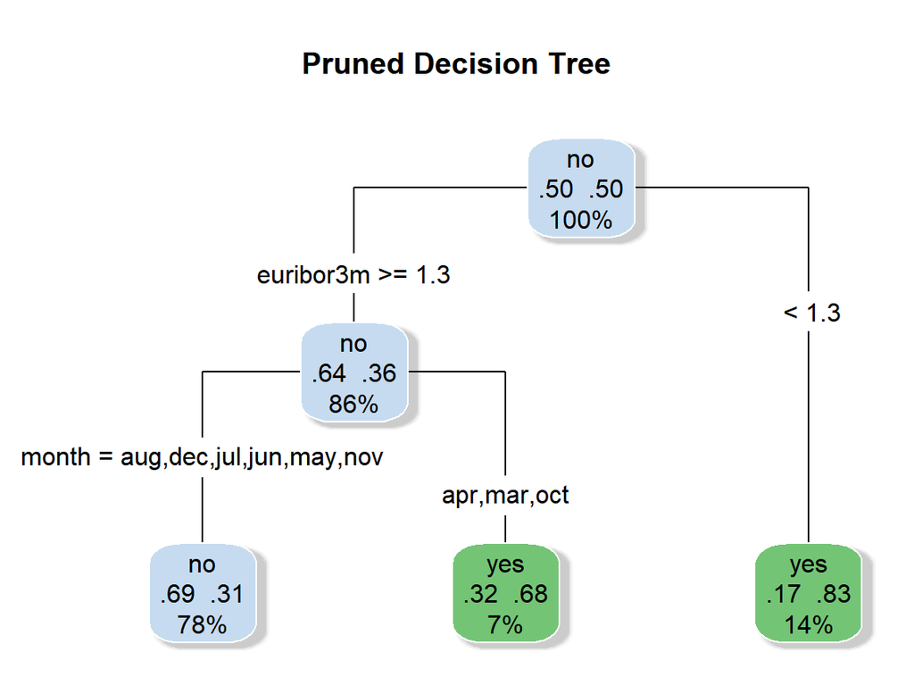

Figure 5: Pruned Decision Tree

### 3.0.3 Model evaluation

Performance on the test set is summarised below in Table 3.

Table 3: Decision Tree: Performance on Test Set

Decision Tree: Performance on Test Set

| Metric | Value |
| --- | --- |
| Accuracy | 0.8095 |
| Sensitivity | 0.5965 |
| Specificity | 0.8369 |
| Balanced Accuracy | 0.7167 |
| AUC | 0.7238 |

Accuracy is a misleading metric here due to the class imbalance in the dataset. A classifier that predicts “no” for every observation would achieve 88.6% accuracy, the No Information Rate, yet the decision tree’s accuracy of 80.95% is lower. This is expected: by assigning equal class priors, the model deliberately trades majority-class accuracy for a better ability to detect true subscribers.

The Positive Predictive Value of 0.320 means that among clients predicted to subscribe, about 32% would do so. Given the base subscription rate of 11.4%, this still represents a substantial improvement in targeting efficiency over random outreach.

## 3.1 Random Forest

```
Call:
 randomForest(formula = y ~ ., data = train_data, ntree = 500,      importance = TRUE)
               Type of random forest: classification
                     Number of trees: 500
No. of variables tried at each split: 4

        OOB estimate of  error rate: 9.8%
Confusion matrix:
      no yes class.error
no  6935 172  0.02420149
yes  612 281  0.68533035
```

### 3.1.1 Model description and justification

Random Forest is an ensemble learning method that constructs a large number of decision trees, each trained on a bootstrap sample of the training data. At each split, only a randomly selected subset of features is considered, which decorrelates the trees and reduces the variance of the ensemble compared to a single decision tree. Predictions are made by majority vote across all trees. This combination of bagging and feature randomisation makes Random Forest particularly robust to overfitting and well suited to tabular classification problems with mixed variable types.

```
mtry = 4  OOB error = 9.9%
Searching left ...
mtry = 3    OOB error = 9.65%
0.02525253 0.01
mtry = 2    OOB error = 9.56%
0.009067358 0.01
Searching right ...
mtry = 6    OOB error = 9.96%
-0.03238342 0.01
```

```
      mtry OOBError
2.OOB    2 0.095625
3.OOB    3 0.096500
4.OOB    4 0.099000
6.OOB    6 0.099625
```

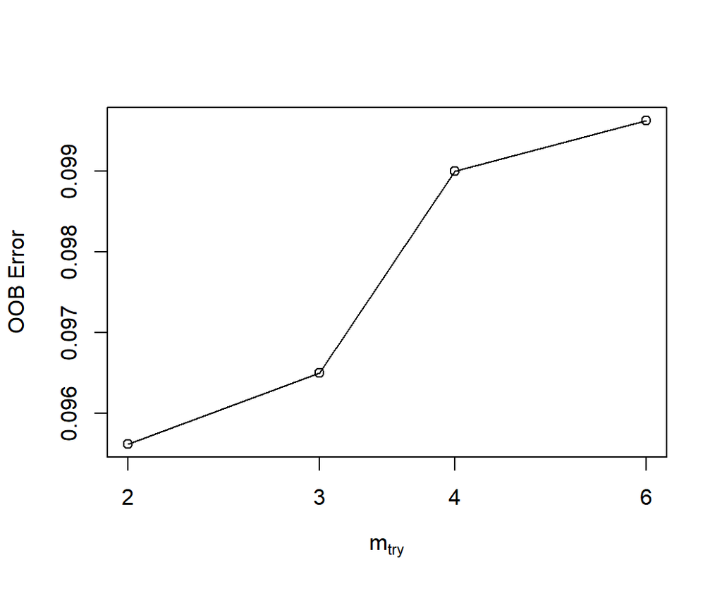

Figure 6: OOB Error vs mtry for Random Forest Tuning

### 3.1.2 Hyperparameter tuning

The key hyperparameter in Random Forest is `mtry`, the number of variables randomly considered at each split. The default value in R for classification is $\lfloor\sqrt{p}\rfloor$, where $p$ is the number of predictors, giving `mtry = 4` in this case. To find the optimal value, `tuneRF` was applied, evaluating each candidate using Out-of-Bag (OOB) error on the training data. As shown in Figure 6, OOB error is minimised at `mtry = 2` (OOB error = 9.56%), with error increasing as `mtry` grows.

```
Optimal threshold: 0.083
```

### 3.1.3 Handling class imbalance

The default classification threshold of 0.5 is poorly suited to imbalanced data, as it systematically under-predicts the minority class. Adjusting class weights was explored but found to reduce AUC by distorting the model’s probability estimates. Instead, the threshold was optimised after fitting using Youden’s J statistic, which identifies the value that maximises the sum of Sensitivity and Specificity simultaneously. The optimal threshold was 0.083, which reflects the low base rate of subscription (11.4%) in the dataset.

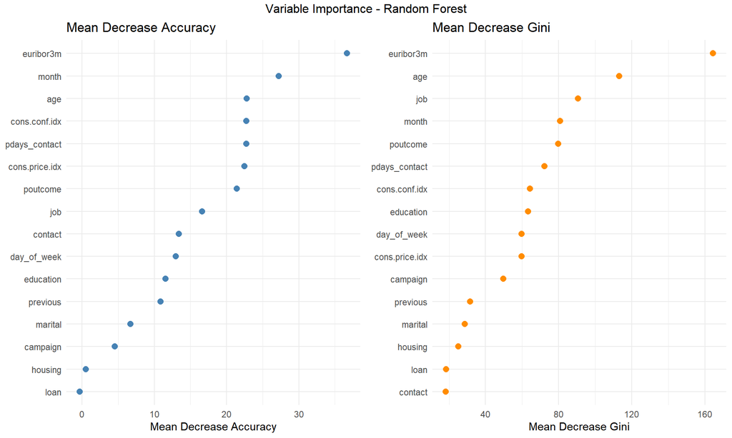

Figure 7: Variable Importance Plot - Random Forest (Mean Decrease in Accuracy and Gini)

### 3.1.4 Variable importance

Figure 7 presents variable importance under two measures. Mean Decrease in Accuracy captures how much predictive performance drops when a variable’s values are randomly permuted, providing a direct measure of its contribution to model accuracy. Mean Decrease in Gini reflects the total reduction in node impurity attributable to each variable across all trees.

### 3.1.5 Model evaluation

Performance on the test set at the optimal threshold is summarised in Table 4.

Table 4: Random Forest: Performance on Test Set

Random Forest: Performance on Test Set

| Metric | Value |
| --- | --- |
| Accuracy | 0.8405 |
| Sensitivity | 0.6360 |
| Specificity | 0.8668 |
| Balanced Accuracy | 0.7514 |
| AUC | 0.7888 |

The Random Forest outperforms the single decision tree across all key metrics. An AUC of 0.789 indicates that the model correctly ranks a randomly chosen subscriber above a randomly chosen non-subscriber approximately 79% of the time. Sensitivity of 0.636 means that roughly two thirds of true subscribers are correctly identified, an improvement over the decision tree (0.597). Specificity remains high at 0.867, confirming that this gain is not achieved by predicting “yes” indiscriminately. The Balanced Accuracy of 0.751 reflects a reasonable trade-off between the two classes given the degree of imbalance present.

The Positive Predictive Value of 0.381 indicates that among clients flagged as likely subscribers, 38% would actually subscribe. This is more than three times the base subscription rate of 11.4%, meaning the model would considerably improve the efficiency of targeted outreach compared to contacting clients at random.

# 4 Conclusions